# HW6: Forest Size Sensitivity using Sobol and ODE

Nick McManus

2023-05-19

```r
knitr::opts_chunk$set(echo = TRUE, message = FALSE, warning = FALSE)
library(sensitivity)  ## Sobol
library(deSolve)      ## ode solver
library(kableExtra)   ## nice tables
library(tidyverse)    ## always
library(here)         ## stable file paths
```

## ODE solver w/o sensitivity

First we’ll run the model (using the ODE solver) to determine the forest size after 300 years and visualize the results. For this run, we’ll make the following assumptions:

- initial forest size (Cinitial) of 10 kgC
- canopy closure threshold (closure) of 50 kgC
- carrying capacity (K) of 250 kgC
- growth rate before canopy closure (r) of 0.01
- growth rate after canopy closure (g) of 2 kg/yr

```r
## read in function
source(here("R/forest_growth.R"))

## set initial forest size
Cinitial = 10

## set parameter values then bind as df
k = 250
r = 0.01
g = 2
closure = 50

params = cbind.data.frame(k, r, g, closure)


## sequence of times for 300 years
simtime = seq(from = 1, to = 300)


## Run ODE solver and save results as df
result = ode(y = Cinitial, times = simtime, func = forest_growth, parms = params)
colnames(result) = c("time", "C")
result = as.data.frame(result)
```

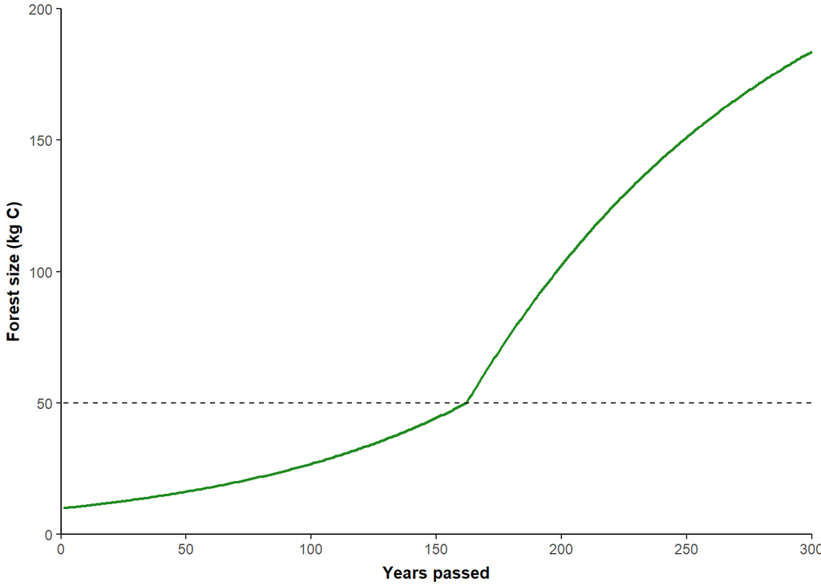

```r
## Visualize results
ggplot(result, aes(x = time, y = C)) +
  geom_line(size = 0.8, color = "forestgreen")+
  labs(x = "Years passed",
       y = "Forest size (kg C)") +
  scale_x_continuous(limits = c(0, 300), breaks = seq(0, 300, by=50), expand = c(0,0))+
  scale_y_continuous(limits = c(0, 200), expand = c(0,0)) +
  geom_line(y = 50, linetype = 'dashed') +
  theme_classic() +
  theme(
    axis.title.x = element_text(size = 10, face = 'bold', vjust = -0.5),
    axis.title.y = element_text(size = 10, face = 'bold', vjust = 2)
  )
```

**Figure 1.** Forest size (kg C) over 300 years based on given growth rates before and after meeting a canopy closure threshold (marked with dashed line). At 100 years, the forest size is 26.91 kg C. The maximum forest size during this period is 183.72 kg C.

## Sobol global

Now we’ll perform a sensitivity analysis that explores how changes in three parameters – r, g, and K – change two metrics of interest: maximum forest size over the 300 years, and forest size after 100 years. When creating sample values for the parameters, we’ll assume a normal distribution with standard deviation of 10%

First, create a sample of parameter values using sobol.

```r
## all will have standard dev of 10%
sd = 0.1
## we'll make 1000 for each
nsample = 1000


## create two samples of parameter values
r_sobol = rnorm(mean = r, sd = r*sd, n = nsample)
g_sobol = rnorm(mean = g, sd = g*sd, n = nsample)
k_sobol = rnorm(mean = k, sd = k*sd, n = nsample)
param1 = cbind.data.frame(r = r_sobol, g = g_sobol, k = k_sobol)

r_sobol = rnorm(mean = r, sd = r*sd, n = nsample)
g_sobol = rnorm(mean = g, sd = g*sd, n = nsample)
k_sobol = rnorm(mean = k, sd = k*sd, n = nsample)
param2 = cbind.data.frame(r = r_sobol, g = g_sobol, k = k_sobol)

## fix in case you get negatives
param1 = param1 %>% map_df(pmax, 0)
param2 = param2 %>% map_df(pmax, 0)

## get sobol object from parameter sets
sens_c = sobolSalt(model = NULL, X1 = param1, X2 = param2, nboot = 300)

## view outputs
# head(sens_c$X)

## rename columns
colnames(sens_c$X) = c("r", "g", "k")
```

Now we’ll create a wrapper function so that we can use `map()` to run the ODE solver and find the metrics of interest for each set of parameters. The one parameter we are not changing is the canopy closure threshold, which remains at 50 kgC.

```r
## create wrapper fxn to run ODE and return max forest size
c_wrapper = function(r, g, k, closure, Cinitial, times, func) {
    ## turn params into list for ODE solver
    params = list(r=r, g=g, k=k, closure=closure)
    result = ode(y=Cinitial, times=times, func=func, parms=params)
    ## rename columns and turn into df
    colnames(result)=c("time","C")
    result = as.data.frame(result)

    ## get max forest size overall and at 100 yrs
    c_max = max(result$C)
    c_100 = result$C[100]
  return(list(c_max = c_max, c_100 = c_100))
}


## now use pmap to run our c_wrapper fxn over
## a vector of parameter values from our sobol output
allresults = as.data.frame(sens_c$X) %>%
  pmap(c_wrapper, closure = closure, Cinitial = Cinitial,
       times = simtime, func = forest_growth)

## extract values from bad list format
allres = allresults %>% map_dfr(`[`,c("c_max", "c_100"))
```

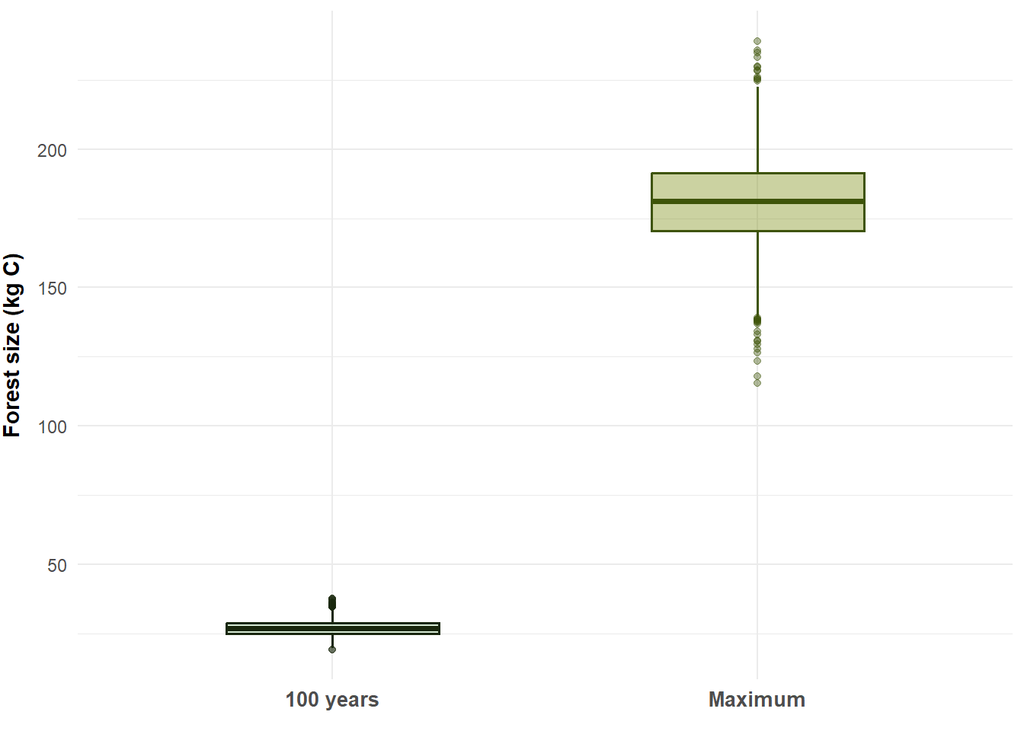

```r
### Now visualize the sensitivity results!

## pivot df so that you can adjust width box plot lol
allres_tidy = allres %>%
  gather(key = "metric", value = "value")

## create the boxplot
ggplot(data = allres_tidy, aes(x = metric, y = value, color = metric, fill = metric)) +
  geom_boxplot(alpha = 0.4, size = 0.7, width = 0.5) +
  labs(y = "Forest size (kg C)",
       x = element_blank())+
  scale_color_manual(values=c("#19270d", "#3E5409")) +
  scale_fill_manual(values=c("darkseagreen3", "#7E8F13")) +
  scale_x_discrete(labels = c("100 years", "Maximum")) +
  theme_minimal() +
  theme(
    axis.title.y = element_text(vjust = 3, face = 'bold'),
    axis.text.x = element_text(face = 'bold', size = 10),
    legend.position = "none"
  )
```

**Figure 2.** Sensitivity analysis of maximum forest size (kg C) and forest size after 100 years. The forest growth model was run with varying growth rates before and after the canopy closure threshold as well as forest carrying capacity. The mean maximum forest size is 180.95 kg C, while the mean forest size after 100 years is 27.01 kg C.

```r
## sobol indices
sens_forest_max = sensitivity::tell(sens_c, allres$c_max)
sens_forest_100 = sensitivity::tell(sens_c, allres$c_100)
```

```
## [1] "All values of t are equal to  1.00000000000003 \n Cannot calculate confidence intervals"
```

```r
## total indices for both metrics (max and 100 yrs)
sens_T_max <- as.data.frame(sens_forest_max$T)
row.names(sens_T_max) <- NULL
sens_T_max <- add_column(.data = sens_T_max,
                         metric = c("max size", "max size", "max size"),
                         parameter = c("r", "g", "k"),
                         .before = 1)

sens_T_100 <- as.data.frame(sens_forest_100$T)
row.names(sens_T_100) <- NULL
sens_T_100 <- add_column(.data = sens_T_100,
                         metric = c("100 years", "100 years", "100 years"),
                         parameter = c("r", "g", "k"),
                         .before = 1)

## bind into one df
sens_T<- rbind(sens_T_max, sens_T_100)


## Repeat for first order index
sens_S_max <- as.data.frame(sens_forest_max$S)
row.names(sens_S_max) <- NULL
sens_S_max <- add_column(.data = sens_S_max,
                         metric = c("max size", "max size", "max size"),
                         parameter = c("r", "g", "k"),
                         .before = 1)

sens_S_100 <- as.data.frame(sens_forest_100$S)
row.names(sens_S_100) <- NULL
sens_S_100 <- add_column(.data = sens_S_100,
                         metric = c("100 years", "100 years", "100 years"),
                         parameter = c("r", "g", "k"),
                         .before = 1)

sens_S<- rbind(sens_S_max, sens_S_100)


## put in nice tables
sens_S %>%
  kable(caption = "**Table 1.** First order sobol indices") %>%
  kable_styling(full_width = FALSE,
                bootstrap_options = "hover",
                position = "left")
```

**Table 1.** First order sobol indices

| metric | parameter | original | bias | std. error | min. c.i. | max. c.i. |
| --- | --- | --- | --- | --- | --- | --- |
| max size | r | 0.3397008 | -0.0018658 | 0.0284831 | 0.2817773 | 0.3960262 |
| max size | g | 0.2018652 | 0.0015444 | 0.0295783 | 0.1430080 | 0.2624185 |
| max size | k | 0.3444661 | -0.0001031 | 0.0310867 | 0.2855125 | 0.4089056 |
| 100 years | r | 1.0000000 | 0.0000000 | 0.0000000 | NA | NA |
| 100 years | g | -0.0164381 | -0.0017252 | 0.0309047 | -0.0774570 | 0.0518396 |
| 100 years | k | -0.0164381 | -0.0017252 | 0.0309047 | -0.0774570 | 0.0518396 |

```r
sens_T %>%
  kable(caption = "**Table 2.** Total sobol indices") %>%
  kable_styling(full_width = FALSE,
                bootstrap_options = "hover",
                position = "left")
```

**Table 2.** Total sobol indices

| metric | parameter | original | bias | std. error | min. c.i. | max. c.i. |
| --- | --- | --- | --- | --- | --- | --- |
| max size | r | 0.3919762 | 0.0001730 | 0.0214828 | 0.3478026 | 0.4312603 |
| max size | g | 0.2421389 | 0.0012512 | 0.0140670 | 0.2127906 | 0.2664119 |
| max size | k | 0.3768963 | 0.0007093 | 0.0228178 | 0.3267664 | 0.4191086 |
| 100 years | r | 1.0164381 | 0.0017252 | 0.0309047 | 0.9481604 | 1.0774570 |
| 100 years | g | 0.0000000 | 0.0000000 | 0.0000000 | 0.0000000 | 0.0000000 |
| 100 years | k | 0.0000000 | 0.0000000 | 0.0000000 | 0.0000000 | 0.0000000 |

As shown in Figure 2, the modeled maximum forest size over 300 years is more sensitive than the forest size after 100 years. For both the first order and total sobol indices (Tables 1 and 2, respectively), parameter r has the largest impact on forest size after 100 years. This is because r determines the pre-canopy closure growth rate, and the size of the forest usually does not pass the canopy closure threshold before 100 years (see Figure 1). When looking at the overall maximum forest size, parameters r and K almost equally affect the model output. These results indicate that after the canopy closure threshold is reached, the carrying capacity has a larger effect on modeled forest size than the post-closure growth rate (g). Additionally, it appears that the growth rate before reaching the threshold (r) has a larger effect on overall maximum forest size than g.